# Lecture 1 Exercises

## Short Questions

1. What is the difference between a list and an array?
2. Consider the list

`list_colors = ["red","yellow","green"]`

What is the output of `list_colors[0]` and  
`list_colors[1]`?

1. How do you concatenate two strings?
2. What does the error "not defined" mean?
3. What does the error "could not be broadcast" mean?
4. How do you compute the median of an array?

```python
# Write your answers here as comments:

# 1. A list can store heterogeneous data, such as numbers, strings, objects, etc, while an array can store homogeneous data only.
# 2. The output of list_colors[0] is "red" and the output of list_colors[1] is "yellow."
# 3. We can use the + symbol to concatenate two or more strings.
# 4. It means that Python is trying to use a variable or function that it cannot find in its memory.
# 5. It's a NumPy error. It means you tried to combine two arrays whose shapes don't line up, and NumPy couldn't stretch either one to match the other.
# 6. print(np.median(vec_name))
```

## Long Questions

(a) Import the pandas, matplotlib, and numpy packages

```python
# Write your own code

import pandas as pd
import matplotlib.pyplot as plt
import numpy as np
```

(b) Open the dataset "worldbank_wdi_2019.csv"  
in the "data" folder

- Read it as a pandas object called "wdi"
- Note: This is a subset of the World Development Indicators for 2019
- Each observation represents a different country

```python
# Write your own code

wdi = pd.read_csv('data/worldbank_wdi_2019.csv')
```

(c) Browse the dataset and manually create  
a list of variable names

```python
# Write your own code

# Create a list, e.g. "variable_names = [ "name1", "name2", "name3" ]"
# Manually type the names of the variables
# If you're viewing the dataset from the VS-Code "Variables" tool, you'll
# see an extra column "index". Do not include this in your list.

display(wdi)
variable_names = ["year", "country_name", "life_expectancy", "gdp_per_capita_usd"]
print(variable_names)
```

|  | year | country_name | life_expectancy | gdp_per_capita_usd |
| --- | --- | --- | --- | --- |
| 0 | 2019 | Afghanistan | 63.565 | 500.522664 |
| 1 | 2019 | Albania | 79.282 | 5396.215864 |
| 2 | 2019 | Algeria | 76.474 | 4022.150184 |
| 3 | 2019 | American Samoa | NaN | 13672.576660 |
| 4 | 2019 | Andorra | NaN | 41327.502030 |
| ... | ... | ... | ... | ... |
| 266 | NaN | NaN | NaN | NaN |
| 267 | NaN | NaN | NaN | NaN |
| 268 | NaN | NaN | NaN | NaN |
| 269 | Data from database: World Development Indicators | NaN | NaN | NaN |
| 270 | Last Updated: 12/22/2022 | NaN | NaN | NaN |

271 rows × 4 columns

```
['year', 'country_name', 'life_expectancy', 'gdp_per_capita_usd']
```

(d) Compute descriptive statistics for the fourth  
variable in the dataset

- One way to do this is:

wdi["gdp_per_capita_usd"].describe()

- Do something similar, but with the list you created above.
- Substitute "gdp_per_capita_usd" with a command that  
  automatically extracts the fourth element in the list

```python
# Write your own code

# Remember that the numbering in Python starts at zero
# For example:
# list_colors = ["red","green","yellow"]
# list_colors[2] will output "yellow"

wdi[variable_names[3]].describe()
```

```
count       255.000000
mean      17230.949757
std       25792.183785
min         216.972968
25%        2186.046581
50%        6837.717826
75%       19809.323135
max      199377.481800
Name: gdp_per_capita_usd, dtype: float64
```

(e) Show a scatter plot that shows "gdp_per_capita_usd"  
in the x-axis and "lifexpectancy" in the y-axis. Label the axes.

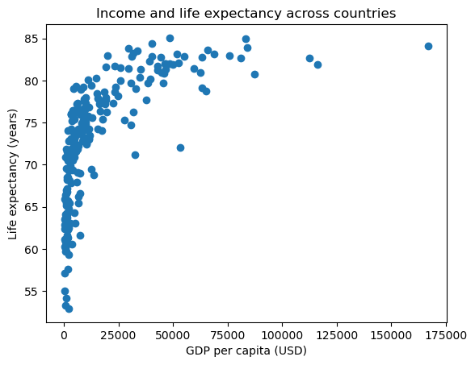

```python
# Write your own code

plt.scatter(x = wdi["gdp_per_capita_usd"], y = wdi["life_expectancy"])
plt.xlabel("GDP per capita (USD)")
plt.ylabel("Life expectancy (years)")
plt.title("Income and life expectancy across countries")
plt.show()
```

(f) Generate "vec_x" from a chi-square  
distribution with (df = 1, size = 1000)

- Plot a histogram of each variable, with axis labels, and title
- Create a new variable "vec_y" by the formula  
  $ y = e^x + 2x + 5$
- Plot "vec_x" against "vec_y" and label the axes

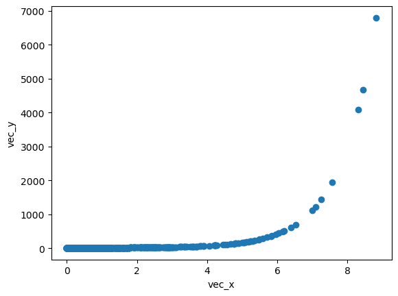

```python
# Write your own code

vec_x = np.random.chisquare(df = 1, size = 1000)
vec_y = np.exp(vec_x) + 2*vec_x + 5
plt.scatter(x = vec_x, y = vec_y)
plt.xlabel("vec_x")
plt.ylabel("vec_y")
plt.show()
```

(g) Research online how to create an array with  
`size = 1000` entries, with all entries equal to one.

- Create a new matrix, `X_mat` that appends a  
  vector with only ones and "vec_x" from question (f) to form  
  a matrix with two columns and 1000 rows
- Compute $(X_{mat}'X_{mat})^{-1}$

```python
# Write your own code

X_mat = np.column_stack([np.ones(len(vec_x)), vec_x])
print(X_mat.shape)

# (X'X)^(-1)
X_mat_t   = np.matrix.transpose(X_mat)
XtX       = np.matmul(X_mat_t, X_mat)
XtX_inv   = np.linalg.inv(XtX)

print(XtX_inv)
```

```
(1000, 2)
[[ 0.00156224 -0.00055955]
 [-0.00055955  0.00055688]]
```